# Factors That Help or Hinder Change (Q8-10)

Janette Avelar

2025-12-23

# Survey Questions

The following figures and tables relate to questions #8-10 in the final survey. All 3 questions used a 4-point Likert scale with an N/A option: - Definitely helps  
- Helps more than hinders  
- Hinders more than it helps  
- Definitely hinders  
- Not applicable (this factor does not exist or is not relevant in our context]

Question 8 asked:  
Thinking about state policy factors, how much does each of the following currently affect your work to achieve your district’s long-term goals?  
- State testing requirements  
- State accountability system  
- Policies that determine how students earn academic credit  
- State graduation requirements  
- State funding formulas  
- State academic standards  
- State postsecondary pathway programs (e.g., early college, apprenticeships)  
- School choice policies  
- State regulatory compliance requirements

Question 9 asked:  
Thinking about local/community factors, how much does each of the following currently affect your work to achieve your district’s long-term goals?  
- Teacher union relationship  
- Family expectations  
- Local political climate  
- School board involvement  
- External partnerships (e.g., local industry, higher ed, city/town, community organizations)  
- The amount of local public funding your district receives (e.g., local taxes, town budget allocation)

Question 10 asked:  
Thinking about other external factors, how much does each of the following currently affect your work to achieve your district’s long-term goals?  
- Guidance from the state Department of Education  
- Guidance from the federal Department of Education  
- Philanthropic funding  
- State funding to participate in new initiatives  
- State professional associations  
- Technical assistance providers  
- Peer learning through participation in networks or consortia  
- State political climate

Out of 307 total districts, 284 respondents answered all three questions and 301 answered at least one. A breakdown of the totals is below.

| Factor | N respondents | Associated question and domain |
| --- | --- | --- |
| State testing requirements | 300 | Q8 - State policy factors |
| State accountability system | 300 | Q8 - State policy factors |
| Policies that determine how students earn academic credit | 297 | Q8 - State policy factors |
| State graduation requirements | 299 | Q8 - State policy factors |
| State funding formulas | 301 | Q8 - State policy factors |
| State academic standards | 300 | Q8 - State policy factors |
| State postsecondary pathway programs | 301 | Q8 - State policy factors |
| School choice policies | 301 | Q8 - State policy factors |
| State regulatory compliance requirements | 299 | Q8 - State policy factors |
| Across all indicators | 301 | Q8 - State policy factors |

[output cut: 16 more lines]

# 6.1 State Policy Factors: Frequency

**Task: % respondents selected each outcome**

I combined 6.1-6.3 into one table that displays all 3 types of factors. The column labeled `Q` indicates which question the factor in that row corresponds to, with Q8 relating to state policy factors, Q9 relating to local community factors, and Q10 relating to external factors. The box at the top of that column allows you to filter the table by whichever factor you’re interested in.

*Note* The percentages here are calculated by the number of respondents for each indicator. Even though a set number of superintendents responded to each question, some elected to not provide a response for certain indicators. In those cases, the denominator is the total number of non-missing respondents.

[interactive table not shown]

# 6.2 Local Community Factors: Frequency

**Task: % respondents selected each outcome**

See 6.1

# 6.3 Other External Factors: Frequency

**Task: % respondents selected each outcome**

See 6.1

# 6.4 Factors Helping

**Task: Mean “helpfulness” score by factor after recoding Likert scale to numeric (e.g., 1 = definitely helps → 4 = definitely hinders)**

*Note:* A lower mean score means the factor was considered **more** helpful.

| Q | Factor | Mean score |
| --- | --- | --- |
| 8 | State testing requirements | 2.71 |
| 8 | State accountability system | 2.82 |
| 8 | Policies that determine how students earn academic credit | 2.4 |
| 8 | State graduation requirements | 2.36 |
| 8 | State funding formulas | 3.4 |
| 8 | State academic standards | 2.09 |
| 8 | State postsecondary pathway programs | 1.84 |
| 8 | School choice policies | 2.79 |
| 8 | State regulatory compliance requirements | 3.04 |
| 9 | Teacher union relationship | 2.31 |

[output cut: 13 more lines]

# 6.5 Most Helpful vs. Most Hindering

**Task: Sorted list of factors by mean score (within category and across all category) rank ordered**

| Factor | Mean score | Ranking |
| --- | --- | --- |
| State funding formulas | 3.4 | 1 |
| Guidance from the federal Department of Education | 3.33 | 2 |
| State regulatory compliance requirements | 3.04 | 3 |
| State political climate | 2.98 | 4 |
| Local political climate | 2.89 | 5 |
| State accountability system | 2.82 | 6 |
| School choice policies | 2.79 | 7 |
| State testing requirements | 2.71 | 8 |
| The amount of local public funding your district receives | 2.6 | 9 |
| Guidance from the state Department of Education | 2.52 | 10 |

[output cut: 13 more lines]

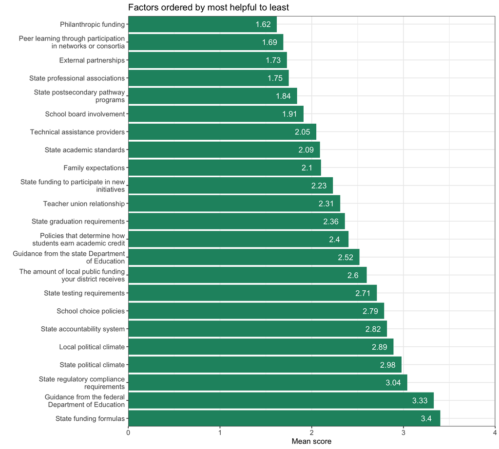

The tables below display the mean score within each category.

**State Policy Factors**

| Factor | Mean score | Ranking |
| --- | --- | --- |
| State funding formulas | 3.4 | 1 |
| State regulatory compliance requirements | 3.04 | 2 |
| State accountability system | 2.82 | 3 |
| School choice policies | 2.79 | 4 |
| State testing requirements | 2.71 | 5 |
| Policies that determine how students earn academic credit | 2.4 | 6 |
| State graduation requirements | 2.36 | 7 |
| State academic standards | 2.09 | 8 |
| State postsecondary pathway programs | 1.84 | 9 |

**Local Community Factors**

[output not shown]

**External Factors**

| Factor | Mean score | Ranking |
| --- | --- | --- |
| Guidance from the federal Department of Education | 3.33 | 1 |
| State political climate | 2.98 | 2 |
| Guidance from the state Department of Education | 2.52 | 3 |
| State funding to participate in new initiatives | 2.23 | 4 |
| Technical assistance providers | 2.05 | 5 |
| State professional associations | 1.75 | 6 |
| Peer learning through participation in networks or consortia | 1.69 | 7 |
| Philanthropic funding | 1.62 | 8 |

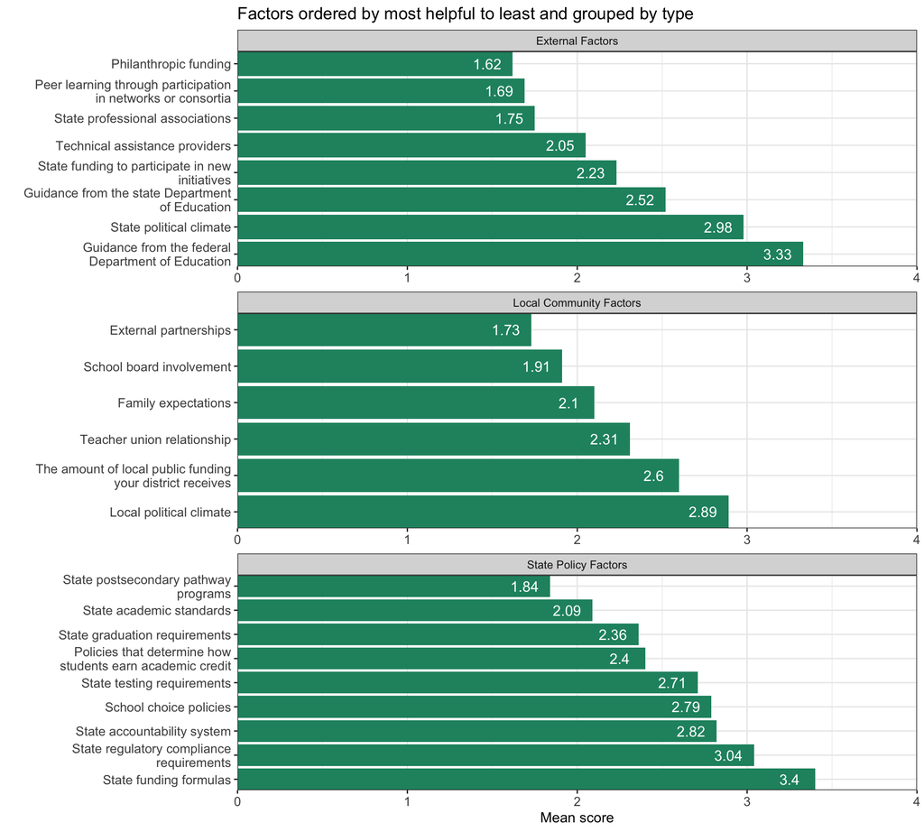

# 6.6 N Factors Helping/Hindering

**Task: Count summary (within category and across all category) of factors helping vs. hindering per district**

The table below (6.6a) displays the number of districts that chose a given number of factors that help or hinder across all categories (state policy factors, local community factors, and external factors) and the average number of factors they selected that help or hinder their work. Out of 23 total factors they could choose from, the maximum selected for both hinders and helps was 23 (N = 1) and the minimum was 0 (N = 1).

On average, respondents selected 12 factors that help change efforts and 8 that hinder change.

| Domain | Average N factors that help | Average N factors that hinder |
| --- | --- | --- |
| External factors | 4 | 2 |
| Local community factors | 4 | 2 |
| State policy factors | 4 | 4 |
| Across all 3 domains | 12 | 8 |

|  | N districts | Helps | Hinders |
| --- | --- | --- | --- |
| Selected 0 factor(s) | 1 | 0 | 0 |
| Selected 4 factor(s) | 1 | 4 | 0 |
| Selected 8 factor(s) | 2 | 2 | 6 |
| Selected 10 factor(s) | 1 | 2 | 8 |
| Selected 11 factor(s) | 1 | 5 | 6 |
| Selected 12 factor(s) | 1 | 7 | 5 |
| Selected 13 factor(s) | 4 | 10 | 4 |
| Selected 14 factor(s) | 3 | 6 | 8 |
| Selected 15 factor(s) | 9 | 7 | 8 |
| Selected 16 factor(s) | 12 | 8 | 8 |

[output cut: 7 more lines]

The following table is comprehensive, with a row for each district displaying the number of factors selected, and how many they indicate help or hinder.

| District ID | N factors selected | Helps | Hinders |
| --- | --- | --- | --- |
| 30680 | 0 | 0 | 0 |
| 30235 | 4 | 4 | 0 |
| 30569 | 8 | 4 | 4 |
| 30764 | 8 | 0 | 8 |
| 30624 | 10 | 2 | 8 |
| 30905 | 11 | 5 | 6 |
| 30605 | 12 | 7 | 5 |
| 30079 | 13 | 9 | 4 |
| 30169 | 13 | 7 | 6 |
| 30208 | 13 | 12 | 1 |

[output cut: 291 more lines]

Tables 6.6c-e below display the average number of factors selected as helping or hindering by category and number of total factors selected.

[output not shown]

| Total factors selected | Number of districts | Helps | Hinders |
| --- | --- | --- | --- |
| 3 | 5 | 2 | 2 |
| 4 | 14 | 3 | 2 |
| 5 | 50 | 3 | 2 |
| 6 | 230 | 4 | 2 |

| Total factors selected | Number of districts | Helps | Hinders |
| --- | --- | --- | --- |
| 1 | 2 | 1 | 0 |
| 2 | 5 | 1 | 2 |
| 3 | 9 | 2 | 2 |
| 4 | 9 | 2 | 2 |
| 5 | 24 | 3 | 2 |
| 6 | 46 | 4 | 2 |
| 7 | 89 | 5 | 2 |
| 8 | 115 | 5 | 3 |